# Executive Summary: Bellabeat Case Study, Smart Device Usage Analysis

Abdullah Aqel

29/12/2025

## Objectives

Analyzes smart device usage data in order discover trends and gain insight into how consumers use *non-Bellabeat* smart devices, and how to apply these insights to *Bellabeat* product, and influence *Bellabeat* marketing strategy.

## Key Findings

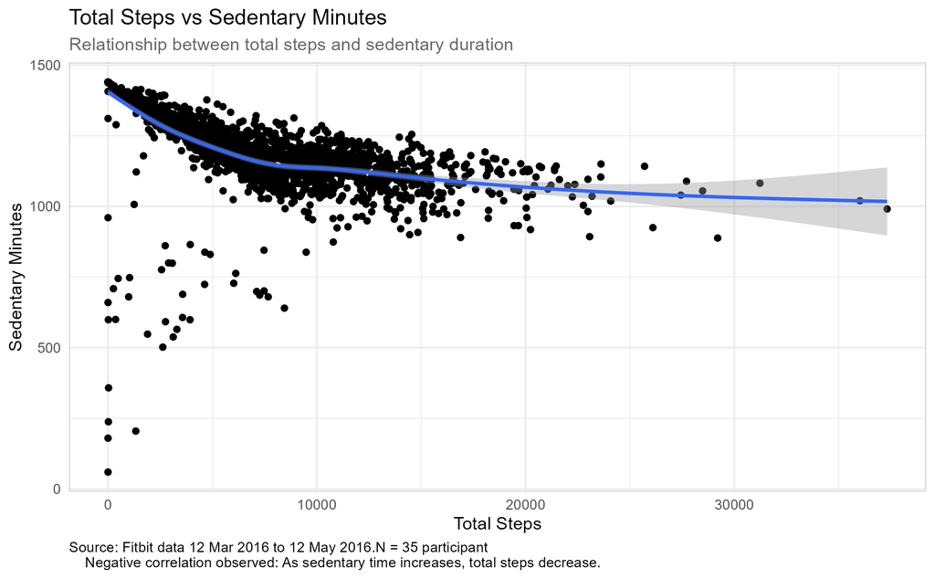

- **Sleep Deprivation:** Over **[54%]** of users fail to reach the recommended 7-9 hours of sleep, directly impacting their activity levels the following day.

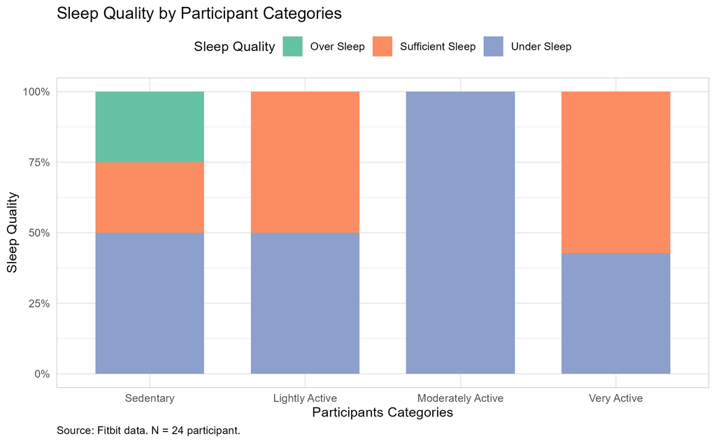

- **Prime Time Activity:** Highest activity levels occur between 5 PM and 7 PM (post-work hours).

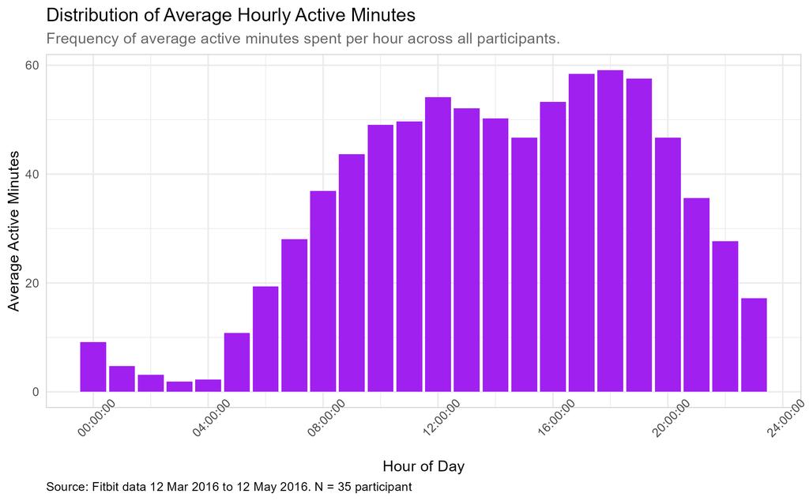

## Proposed Strategy

- **Gamification:** Launch a “7.5k Step Challenge” within the app to motivate users to reach the health baseline.
- **Smart Notifications:** Use a gentle nudge when user is sedentary motivating them to do activity. Use reminders when the user usually has a “gap” in their schedule.
- **Sleep Coaching:** Use “Night-time Wind-down” reminders to help users achieve the 7-9 hour sleep target for optimal recovery.

## Conclusion

By focusing on these behavioral nudges, Bellabeat can transition from a simple tracking tool to an essential wellness partner, increasing user retention and brand loyalty.